# scRNA-seq analysis pipeline

This is a demonstration of scRNA-seq analysis using Seurat on R. scanpy can be used for python users.

This dataset is downloaded from [10X Genomics](https://www.10xgenomics.com/resources/datasets).

The processing steps of raw reads to counts can be done online/running CellRanger Tool on HPC clusters.

# Libraries

```r
library(tidyverse)
library(Seurat)
```

# Load data

```r
pbmc_data = Read10X("../data/filtered_gene_bc_matrices_8kpbmc/GRCh38/")
```

# Seurat object

```r
seurat = CreateSeuratObject(count = pbmc_data,
                            min.cell = 3,
                            project = "PBMC")
```

# QA and filtering

```r
seurat[["percent.mito"]] = PercentageFeatureSet(seurat, pattern = "^MT-") ##calculating mito percentage
```

Lets make violin plots to see if the dataset is of high quality.

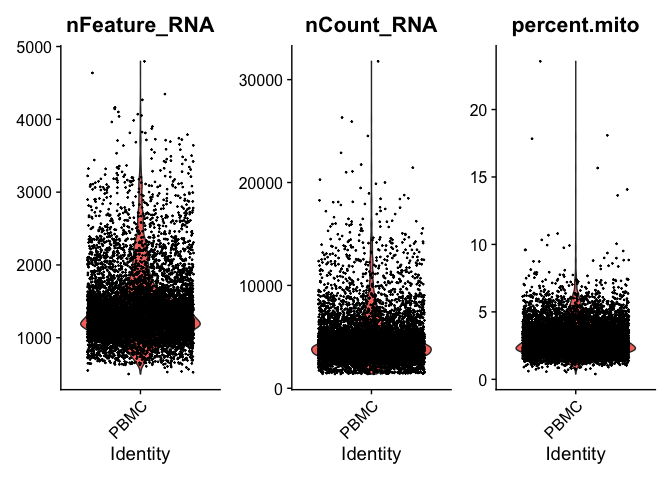

```r
VlnPlot(seurat,
        features = c("nFeature_RNA", "nCount_RNA", "percent.mito"),
        pt.size = .2,
        ncol = 3)
```

As shown above, the number of RNA features and RNA count is really high, which is ideal. The percentage of mitochondrial RNA is also really low (~5%), meaning the dataset is fairly “clean”. (Not many cells bursted)

It is hard to see with all these dots in the way. Let’s make a histogram to inspect percent.mito to find a cutoff.

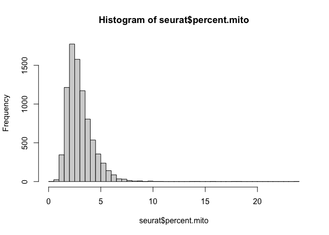

```r
hist(seurat$percent.mito, breaks = 50)
```

Just to see the relation between percent.mito and nFeature_RNA.

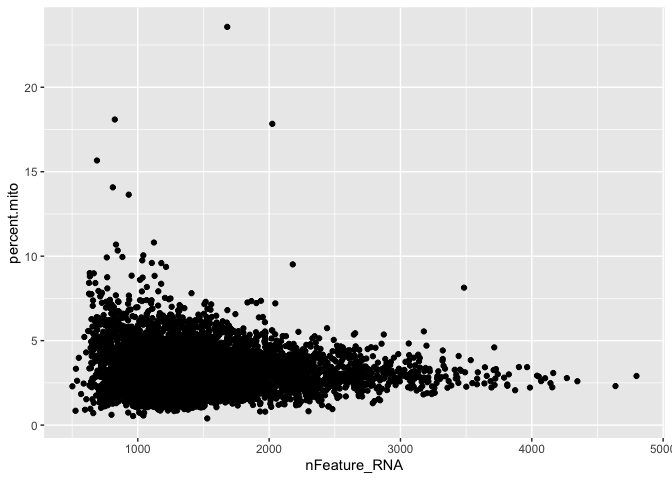

```r
qplot(x=nFeature_RNA, y=percent.mito, data = seurat@meta.data)
```

This is an arbitray threshold, but I am choosing 7.5% as a cutoff here. (dump anything > 7.5% mito)

## Subsetting

Keeping cells with more than 200 RNAs *AND* less than 7.5% mito RNA.

```r
seurat = subset(seurat,
                subset = percent.mito < 7.5 &
                nFeature_RNA > 200)
```

## Normalization (Library-size scaling)

```r
seurat = NormalizeData(seurat)
```

# Dimensionality Reduction

```r
seurat = FindVariableFeatures(seurat,
                              selection.method = "vst",
                              nfeatures = 2000)
```

Looking at top 20 variable genes.

```r
head(VariableFeatures(seurat), n = 20)
```

```
##  [1] "IGLC3"      "IGLC2"      "PPBP"       "FCER1A"     "PF4"
##  [6] "PTGDS"      "GNLY"       "GZMB"       "LILRA4"     "JCHAIN"
## [11] "S100A8"     "SDPR"       "IGKC"       "AL928768.3" "S100A9"
## [16] "HLA-DQA1"   "TUBB1"      "HLA-DRA"    "CD74"       "HLA-DPA1"
```

## PCA: linear DR

```r
seurat = ScaleData(seurat)
seurat = RunPCA(seurat)
```

```
## PC_ 1
## Positive:  LTB, TRAC, CD3D, IL32, TRBC2, CD69, CD3G, CD7, CD27, IL7R
##     IFITM1, RPS2, CD2, LEF1, CCR7, TRBC1, SPOCK2, NOSIP, CD247, CTSW
##     TRAT1, GZMM, MAL, CD8B, CD8A, ITM2A, SYNE2, PIM2, AQP3, CDC25B
## Negative:  CST3, LYZ, CSTA, MNDA, LST1, TYROBP, FCN1, FTL, AIF1, CTSS
##     TYMP, FCER1G, S100A9, RP11-1143G9.4, LGALS1, FTH1, S100A8, LGALS2, SERPINA1, SPI1
##     FGL2, S100A11, GRN, PSAP, CFD, GPX1, AP1S2, MS4A6A, CLEC7A, CD68
## PC_ 2
## Positive:  IL32, CD3D, TMSB4X, CTSW, CD7, TRAC, GZMA, NKG7, S100A4, CST7
##     IFITM1, CCL5, GZMM, CD247, ANXA1, PRF1, CD2, KLRD1, CD3G, PFN1
##     SRGN, S100A6, ITGB2, KLRB1, ID2, HOPX, IL7R, LYAR, KLRG1, GNLY
## Negative:  CD79A, MS4A1, IGHM, IGHD, CD79B, TCL1A, IGKC, LINC00926, BANK1, CD74
##     CD22, HLA-DQB1, HLA-DRA, HLA-DPA1, VPREB3, TNFRSF13C, HLA-DPB1, FCER2, FAM129C, MEF2C
##     RALGPS2, HLA-DRB1, HLA-DQA1, HLA-DOB, FCRLA, SPIB, EAF2, HLA-DMB, HVCN1, TSPAN13
## PC_ 3
## Positive:  LEF1, CCR7, RPS2, MAL, S100A12, JUNB, TRAC, LTB, S100A8, VCAN
##     S100A9, NOSIP, RGCC, RP11-1143G9.4, CD14, LRRN3, IL7R, FCN1, NELL2, RBP7
##     FHIT, FOS, CXCL8, CSTA, CD27, TMSB10, AIF1, SOCS3, MNDA, CD3D
## Negative:  GZMB, NKG7, PRF1, KLRD1, CST7, CLIC3, GZMA, FGFBP2, KLRF1, GNLY
##     HOPX, SPON2, C12orf75, CD160, RHOC, CCL4, CCL5, CTSW, GZMH, XCL2
##     FCGR3A, MATK, CMC1, TRDC, S1PR5, PLEK, ADGRG1, IL2RB, APOBEC3G, TBX21
## PC_ 4
## Positive:  LILRA4, LRRC26, SERPINF1, CLEC4C, IL3RA, SCT, TPM2, DERL3, PPP1R14B, PTCRA
##     PLD4, LINC00996, TNFRSF21, ITM2C, DNASE1L3, SMPD3, LAMP5, MAP1A, GAS6, UGCG
##     PTPRS, RP11-73G16.2, MYBL2, JCHAIN, ASIP, SCAMP5, FCER1A, CCDC50, IRF7, APP
## Negative:  KLRD1, NKG7, FGFBP2, PRF1, CST7, KLRF1, GZMA, CD79B, MS4A1, GNLY
##     HOPX, CD79A, IGHD, CCL4, CD160, FCGR3A, LINC00926, SPON2, XCL2, FCER2
##     S1PR5, TRDC, GZMH, CD22, TTC38, MT-CO1, MATK, ADGRG1, TNFRSF13C, VPREB3
## PC_ 5
## Positive:  RPS2, TMSB10, LILRA4, LRRC26, SERPINF1, IL3RA, PPP1R14B, PLD4, CLEC4C, CCDC50
##     SCT, DERL3, LINC00996, DNASE1L3, TPM2, IRF7, UGCG, TNFRSF21, LILRB4, LAMP5
##     SMPD3, MYBL2, ASIP, SCAMP5, JCHAIN, CORO1A, MT-CO1, GAS6, ITM2C, RP11-117D22.2
## Negative:  SDPR, PPBP, GNG11, TUBB1, PF4, CLU, SPARC, HIST1H2AC, ACRBP, GP9
##     CTTN, ITGA2B, CMTM5, TMEM40, C2orf88, TSC22D1, HRAT92, MMD, MAP3K7CL, NRGN
##     CLDN5, TREML1, HGD, HIST1H2BJ, GMPR, CA2, CD9, MYLK, SH3BGRL2, ESAM
```

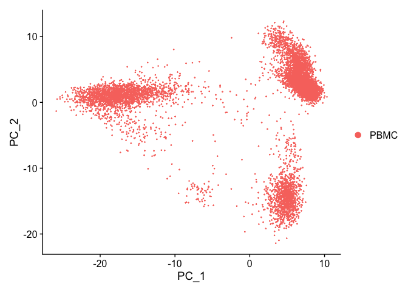

```r
DimPlot(seurat)
```

Just randomly picking 4 genes from PC_1 to show heterogeneity.

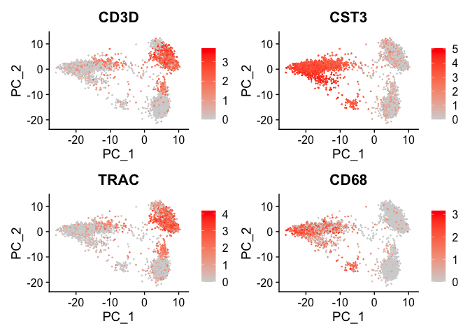

```r
FeaturePlot(seurat, features = c("CD3D", "CST3", "TRAC", "CD68"), cols = c("lightgrey","red"))
```

To see how many PCs are capturing the difference (probably 25? 30?)

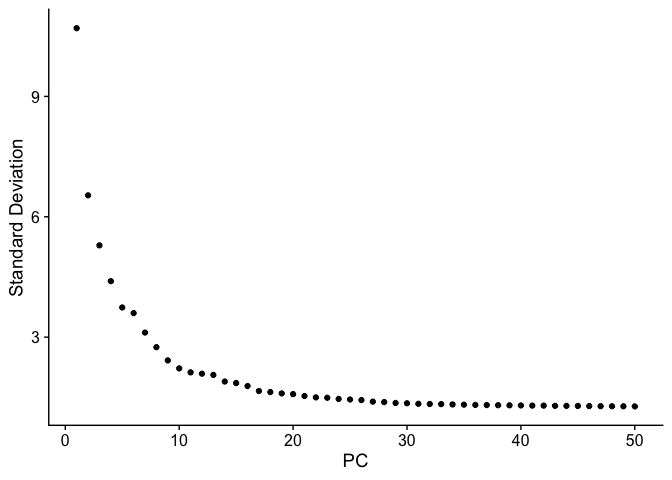

```r
ElbowPlot(seurat, ndims = 50)
```

## UMAP: non-linear DR

Not using t-SNE because it is basically inferior.

[UMAP displays global structures while t-SNE does not.](https://blog.bioturing.com/2022/01/14/umap-vs-t-sne-single-cell-rna-seq-data-visualization/#:~:text=t%2DSNE%20and%20UMAP%20have,UMAP%20compresses%20that%20graph.)

```r
seurat = RunUMAP(seurat, dims = 1:30)
```

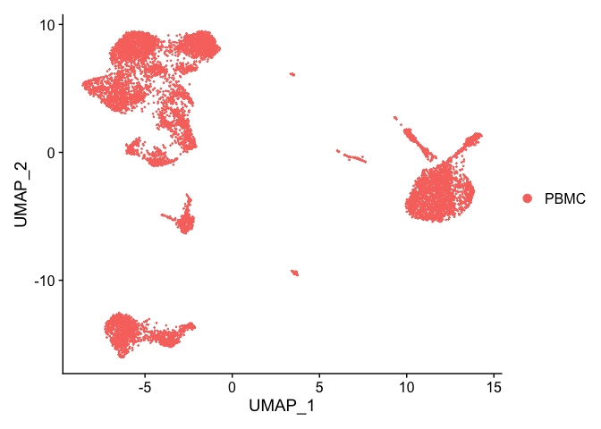

```r
DimPlot(seurat)
```

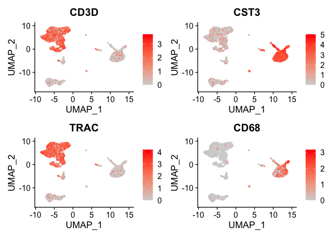

```r
FeaturePlot(seurat, features = c("CD3D", "CST3", "TRAC", "CD68"), cols = c("lightgrey","red"))
```

# Clustering

```r
seurat = FindNeighbors(seurat, dims = 1:30)
seurat = FindClusters(seurat, resolution = 0.2)
```

```
## Modularity Optimizer version 1.3.0 by Ludo Waltman and Nees Jan van Eck
##
## Number of nodes: 8337
## Number of edges: 347595
##
## Running Louvain algorithm...
## Maximum modularity in 10 random starts: 0.9555
## Number of communities: 13
## Elapsed time: 0 seconds
```

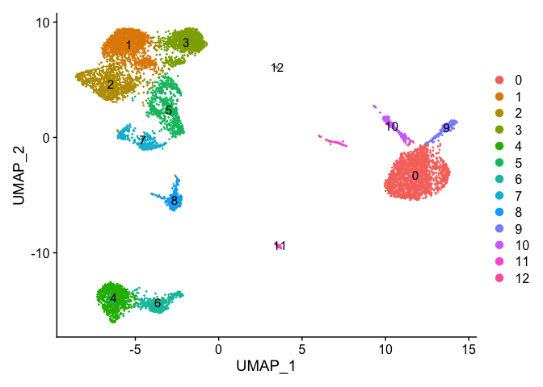

```r
DimPlot(seurat, label = T)
```

```r
cluster_markers = FindAllMarkers(seurat,
                                 logfc.threshold = 0.5,
                                 only.pos = T)
top_genes = cluster_markers %>%
  group_by(cluster) %>%
  top_n(1, avg_log2FC) %>%
  pull(gene)
```

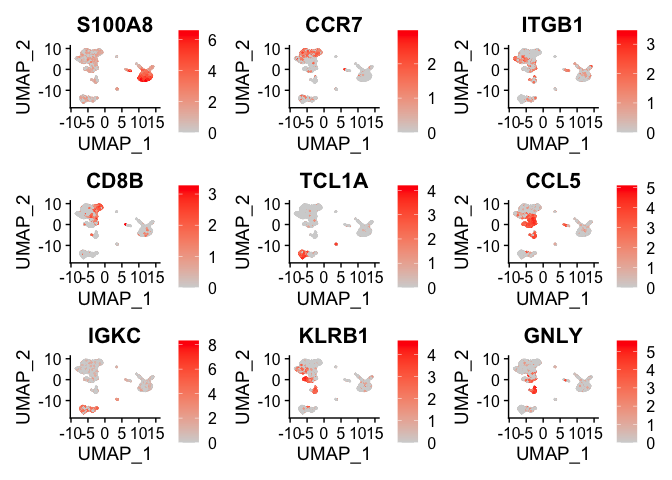

```r
FeaturePlot(seurat, features = top_genes[1:9],
            cols = c('lightgrey', 'red'),
            pt.size = 0.1)
```

# Other visualization tools

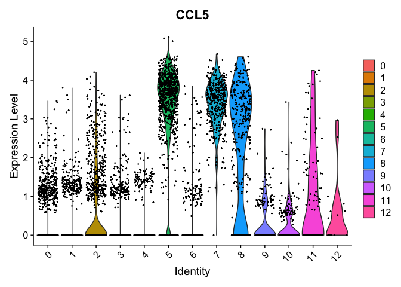

```r
VlnPlot(seurat, features = "CCL5", pt.size = 0.3)
```

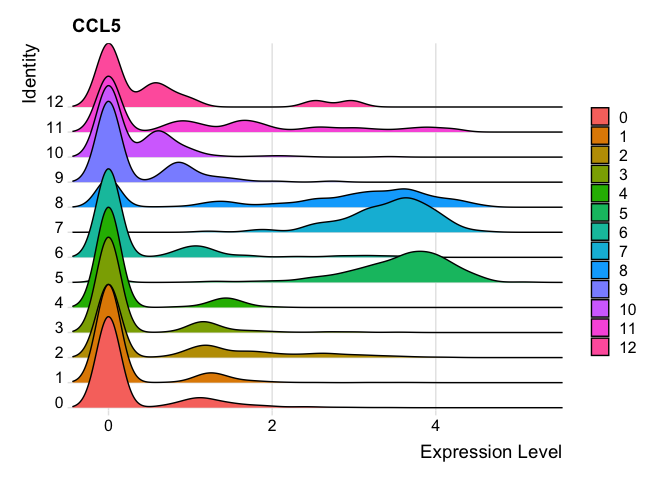

```r
RidgePlot(seurat, features =  "CCL5")
```

# Differential Expression

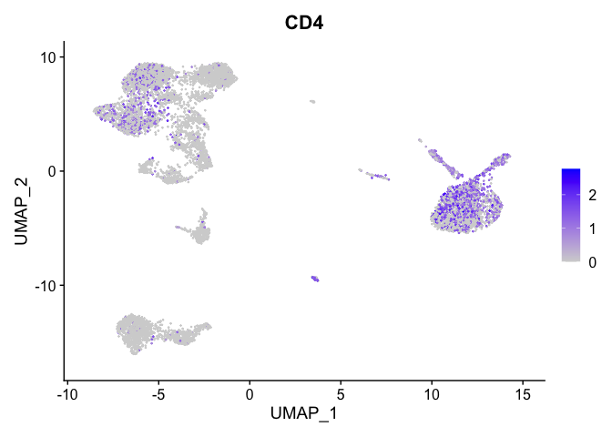

```r
FeaturePlot(seurat, features = "CD4")
```

From this, just pretend:

Cluster 0 = Memory CD4 T cells

Cluster 3 = Naive CD4 cells

```r
dge_tcells = FindMarkers(seurat,
                         ident.1 = 0,
                         ident.2 = 3,
                         only.pos = F,
                         logfc.threshold = 0)
```

## GSEA

```r
library(fgsea)
```

### Loading gmt data

These data can be found [here](http://www.gsea-msigdb.org/gsea/msigdb/collections.jsp)

```r
hallmarks = gmtPathways("../data/hallmark.genesets.v6.1.symbols.gmt")
kegg = gmtPathways("../data/kegg.genesets.v6.1.symbols.gmt")
reactome = gmtPathways("../data/reactome.genesets.v6.1.symbols.gmt")
go = gmtPathways("../data/GOTerms.BP.v6.1.symbols.gmt")

gene_sets = c(hallmarks, kegg, reactome, go)
```

Pairing gene names with fold change.

```r
dge_tcells$gene = rownames(dge_tcells)
dge_tcells = dge_tcells %>%
  arrange(desc(avg_log2FC))
fold_changes = dge_tcells$avg_log2FC
names(fold_changes) = dge_tcells$gene
```

```r
gsea_tcell = fgsea(pathways = gene_sets,
                   stats = fold_changes,
                   minSize = 5,
                   maxSize = 5000,
                   nproc = 2)
gsea_sig = filter(gsea_tcell, padj <= 0.05) %>%
  arrange(NES)
```

### Gene Set Scoring

Seurat has a function to score each cell for a set of pre-defined genes.

```r
head(gsea_sig)
```

```
##                                                                   pathway
## 1:                                      REACTOME_PEPTIDE_CHAIN_ELONGATION
## 2: REACTOME_NONSENSE_MEDIATED_DECAY_ENHANCED_BY_THE_EXON_JUNCTION_COMPLEX
## 3:                       REACTOME_3_UTR_MEDIATED_TRANSLATIONAL_REGULATION
## 4:                                                          KEGG_RIBOSOME
## 5:  GO_NUCLEAR_TRANSCRIBED_MRNA_CATABOLIC_PROCESS_NONSENSE_MEDIATED_DECAY
## 6:             REACTOME_INFLUENZA_VIRAL_RNA_TRANSCRIPTION_AND_REPLICATION
##            pval         padj  log2err         ES       NES size
## 1: 3.197265e-41 4.247034e-38 1.671997 -0.8856855 -3.548200   83
## 2: 3.467566e-40 3.454562e-37 1.653315 -0.8521483 -3.527673   96
## 3: 4.810033e-43 1.916798e-39 1.708748 -0.8527639 -3.515888  102
## 4: 7.529579e-38 5.000895e-35 1.602431 -0.8661764 -3.510997   85
## 5: 2.594270e-41 4.247034e-38 1.671997 -0.8453954 -3.485508  102
## 6: 5.010968e-38 3.993742e-35 1.602431 -0.8361947 -3.433832   98
##                              leadingEdge
## 1: RPSA,RPS29,RPL31,RPL3,RPL23A,RPS5,...
## 2: RPSA,RPS29,RPL31,RPL3,RPL23A,RPS5,...
## 3: RPSA,RPS29,RPL31,RPL3,RPL23A,RPS5,...
## 4: RPSA,RPS29,RPL31,RPL3,RPL23A,RPS5,...
## 5: RPSA,RPS29,RPL31,RPL3,RPL23A,RPS5,...
## 6: RPSA,RPS29,RPL31,RPL3,RPL23A,RPS5,...
```

Using “REACTOME_3_UTR_MEDIATED_TRANSLATIONAL_REGULATION”

```r
seurat = AddModuleScore(seurat,
                        features = gene_sets["REACTOME_3_UTR_MEDIATED_TRANSLATIONAL_REGULATION"],
                        name = "REACTOME_3_UTR_MEDIATED_TRANSLATIONAL_REGULATION")
```

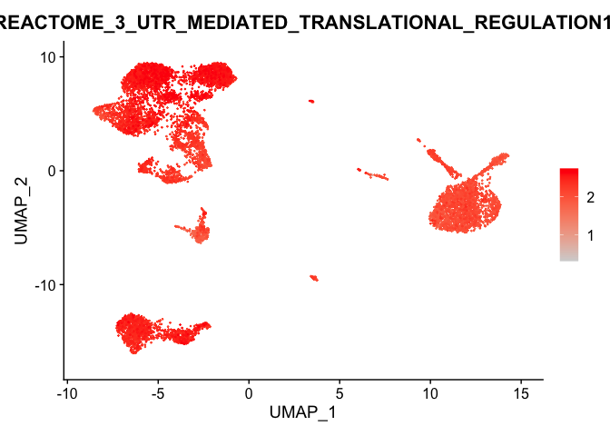

```r
FeaturePlot(seurat,
            features = 'REACTOME_3_UTR_MEDIATED_TRANSLATIONAL_REGULATION1',
            cols = c('lightgrey', 'red'),
            order = T)
```

Cannot really see the difference, perhaps quantitative plots will show the difference better.

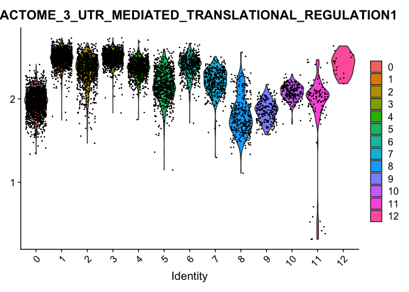

```r
VlnPlot(seurat,
        features = 'REACTOME_3_UTR_MEDIATED_TRANSLATIONAL_REGULATION1',
        pt.size = 0.1)
```

Just to visualize between clusters 0 and 3.

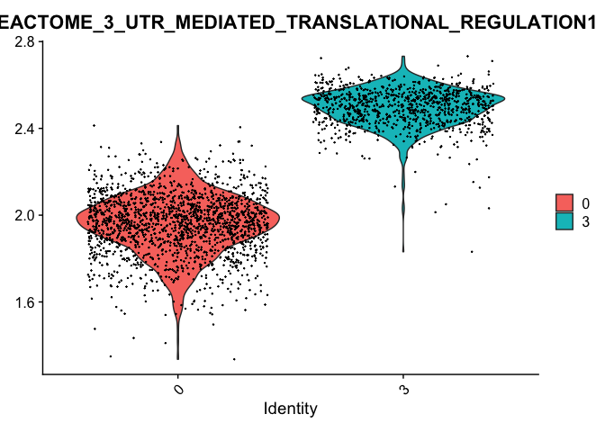

```r
VlnPlot(seurat,
        features = 'REACTOME_3_UTR_MEDIATED_TRANSLATIONAL_REGULATION1',
        pt.size = 0.1,
        idents = c(0,3))
```

## Generic pathway activity

```r
library(progeny)
library(dorothea)
```

PROGENy is resource that leverages a large compendium of publicly available signaling perturbation experiments to yield a common core of pathway responsive genes for human and mouse. These, coupled with any statistical method, can be used to infer pathway activities from bulk or single-cell transcriptomics.

```r
exp_mat <- as.matrix(seurat[["RNA"]]@data)
pathways <- progeny(exp_mat,
                    scale=T,
                    organism="Human")
head(pathways)
```

```
##                      Androgen       EGFR    Estrogen    Hypoxia    JAK-STAT
## AAACCTGAGCATCATC-1  0.3739243 -0.4210440 -0.78385318 -1.1249665  0.67011656
## AAACCTGAGCTAACTC-1  2.7119002  0.2909708 -0.03740632 -1.8433863 -1.71976461
## AAACCTGAGCTAGTGG-1 -0.5505979  0.8010731 -1.29041327 -0.1874210 -0.39791280
## AAACCTGCACATTAGC-1 -0.3145123 -0.7765205  0.47579680 -0.6871366 -0.57441065
## AAACCTGCACTGTTAG-1 -0.7444938 -0.6553544 -0.71494058  0.3190308  0.09406944
## AAACCTGCATAGTAAG-1 -1.0022811  1.9276188  1.03985549  0.8439905 -0.67957704
##                           MAPK        NFkB         p53       PI3K       TGFb
## AAACCTGAGCATCATC-1 -1.20917331 -0.57688702  0.07485003 -1.0042793 -0.3322471
## AAACCTGAGCTAACTC-1 -0.08691169  2.53382293  1.95327039  0.9286018 -0.8537470
## AAACCTGAGCTAGTGG-1  0.37064068  0.60223197 -0.69110332 -0.4516438 -0.8537470
## AAACCTGCACATTAGC-1 -0.06118787 -0.57720013  0.09310605  0.6141208 -0.8537470
## AAACCTGCACTGTTAG-1  0.11030241 -0.05813758  1.20997367  0.8426313  0.4057307
## AAACCTGCATAGTAAG-1  1.57816952  2.73578623  0.60775587  1.3185506  2.1414269
##                          TNFa       Trail       VEGF         WNT
## AAACCTGAGCATCATC-1 -0.5247113  0.33435896 -2.2811348 -0.89091415
## AAACCTGAGCTAACTC-1  1.9345054  0.45856154  0.4521791  0.09653278
## AAACCTGAGCTAGTGG-1  0.9729998 -1.53629839  0.4521791 -0.57886926
## AAACCTGCACATTAGC-1 -1.1875851  0.98301596  0.4521791 -0.49894987
## AAACCTGCACTGTTAG-1 -0.1982560  0.24193442 -1.7321771  0.29473206
## AAACCTGCATAGTAAG-1  2.7259701 -0.02727536  0.5453691  0.18776337
```

We can add all of this data into our metadata

```r
seurat@meta.data <- cbind(seurat@meta.data, pathways)
```

And visualize activities. I’ll just get a list of the different pathways from the column names of that “pathways” variable

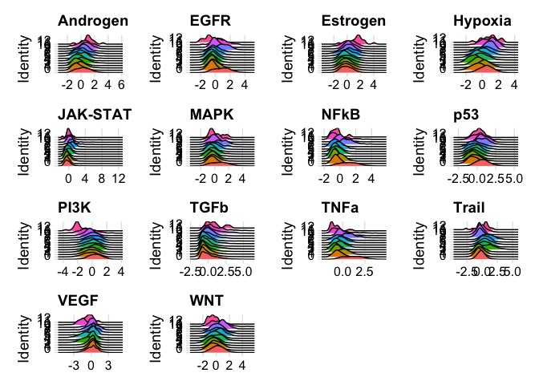

```r
RidgePlot(seurat, features = colnames(pathways), ncol = 4)
```